# PDX: Drug trails

Olaparib stroma

Alistair Martin

Last modified: 03 Nov 2017

# Load libraries, functions and data

```
Read 61.8% of 113262 rows
Read 113262 rows and 722 (of 722) columns from 0.169 GB file in 00:00:04
```

# QC

This QC check was performed for the human reads. Let us proceeed to remove the same samples and merge.

```r
rnaseq <- subset.PDX(rnaseq, rnaseq$meta[,!(Sample.name %in% c("PDX124 Control resist OR (epp 14)_PDX124OR control2","201STG_ Olaparib-response_6350L_12R"))])
rnaseq <- merge.PDX(rnaseq)
rnaseq$meta <- merge(rnaseq$meta,meta,sort=F)
rnaseq$meta[,merged.lanes:=as.numeric(as.factor(merged.lanes))]
```

# Key questions

- Are there any systematic differences between the control and treated groups?
- Are there any traits/markers that define the speed with which resistance is devloped in the treated groups?
- Is the transcriptome of the control group similar between mice?
- Is resistance developed in different manners between the treated samples?

# PCAs

```r
pca <- pca.run(rnaseq$mouse)
summary(pca)
```

```
Importance of components:
                           PC1     PC2     PC3     PC4     PC5     PC6     PC7     PC8     PC9    PC10    PC11
Standard deviation     23.3995 10.5939 7.75718 7.25891 6.44022 6.12820 5.12224 4.74026 4.34401 3.82192 3.63433
Proportion of Variance  0.5475  0.1122 0.06017 0.05269 0.04148 0.03755 0.02624 0.02247 0.01887 0.01461 0.01321
Cumulative Proportion   0.5475  0.6598 0.71994 0.77263 0.81411 0.85166 0.87790 0.90037 0.91924 0.93385 0.94706
                          PC12    PC13    PC14   PC15    PC16    PC17    PC18    PC19    PC20    PC21      PC22
Standard deviation     3.26788 3.03147 2.80082 2.5297 2.27152 1.97143 1.79310 1.68665 1.57109 1.12068 4.769e-15
Proportion of Variance 0.01068 0.00919 0.00784 0.0064 0.00516 0.00389 0.00322 0.00284 0.00247 0.00126 0.000e+00
Cumulative Proportion  0.95774 0.96693 0.97477 0.9812 0.98633 0.99022 0.99343 0.99628 0.99874 1.00000 1.000e+00
```

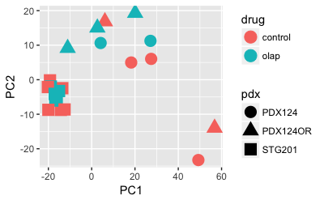

```r
pca <- cbind(rnaseq$meta,pca$x)
ggplot(pca) + aes(x=PC1,y=PC2,col=drug,shape=pdx) + geom_point(size=5)
```

Clear differences between the two PDX models. Interestingly the PDX124 and PDX124OR appear to be relatively similar. However, there is clearly a second group of outliers that need to be explained. These samples are:

```r
pca[PC2>10,Sample.name]
```

[output not shown]

```r
outliers <- c("PDX124 Control WT (epp 2)_PDX124wt control2","PDX124 Control resist OR (epp 13)_PDX124OR control1")
rnaseq <- subset.PDX(rnaseq,rnaseq$meta[,!(Sample.name %in% outliers)])
```

Let us repeat the PCA having removed these outliers and account for the PDX batch effects.

```r
y <- pca.prep(rnaseq$mouse)
y <- removeBatchEffect(y,design = model.matrix(~rnaseq$meta$drug), batch= rnaseq$meta$pdx)
pca <- prcomp(t(y),scale=T)
summary(pca)
```

```
Importance of components:
                           PC1     PC2     PC3     PC4     PC5     PC6     PC7    PC8     PC9    PC10    PC11
Standard deviation     15.7941 11.7169 10.0174 9.67286 9.08415 8.31233 7.58713 6.9212 5.93390 5.52435 5.14203
Proportion of Variance  0.2495  0.1373  0.1003 0.09356 0.08252 0.06909 0.05756 0.0479 0.03521 0.03052 0.02644
Cumulative Proportion   0.2495  0.3867  0.4871 0.58065 0.66317 0.73227 0.78983 0.8377 0.87295 0.90346 0.92991
                          PC12   PC13    PC14    PC15    PC16    PC17      PC18      PC19      PC20
Standard deviation     4.17610 3.8596 3.60718 3.13587 3.01033 2.41888 9.916e-15 8.141e-15 6.821e-15
Proportion of Variance 0.01744 0.0149 0.01301 0.00983 0.00906 0.00585 0.000e+00 0.000e+00 0.000e+00
Cumulative Proportion  0.94735 0.9622 0.97525 0.98509 0.99415 1.00000 1.000e+00 1.000e+00 1.000e+00
```

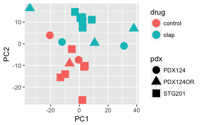

```r
pca <- cbind(rnaseq$meta,pca$x)
ggplot(pca) + aes(x=PC1,y=PC2,col=drug,shape=pdx) + geom_point(size=5)
```

We appear to have a relatively good seperation between the control and the treated groups which will hopefully lead to a some noticable differences in the DE models.

Lastly, there are two experimental batches within the STG201 experiments. Let us perform a pca on the samples from this PDX model only.

```r
x <- subset.PDX(rnaseq,rnaseq$meta[,pdx=="STG201"])
y <- pca.prep(x$mouse)
pca <- prcomp(t(y),scale=T)
summary(pca)
```

```
Importance of components:
                           PC1     PC2     PC3     PC4     PC5     PC6     PC7     PC8     PC9   PC10    PC11
Standard deviation     18.5230 14.0406 12.7122 8.51287 7.88601 6.55290 5.82416 5.28761 4.90611 4.7326 3.49483
Proportion of Variance  0.3431  0.1971  0.1616 0.07247 0.06219 0.04294 0.03392 0.02796 0.02407 0.0224 0.01221
Cumulative Proportion   0.3431  0.5402  0.7018 0.77431 0.83650 0.87944 0.91336 0.94132 0.96539 0.9878 1.00000
                            PC12
Standard deviation     9.826e-15
Proportion of Variance 0.000e+00
Cumulative Proportion  1.000e+00
```

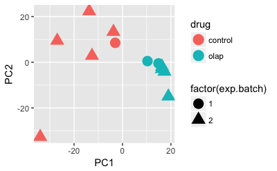

```r
pca <- cbind(x$meta,pca$x)
ggplot(pca) + aes(x=PC1,y=PC2,col=drug,shape=factor(exp.batch)) + geom_point(size=5)
```

While there isn’t a clear outlier in exp.batch. However, we know that one sample in this batch is from a different mother(?). This should confirm this later via exome, however for now we will remove it even though it does not appear different. Otherwise, the exp.bacth effect appears to be minimal.

```r
rnaseq <- subset.PDX(rnaseq,rnaseq$meta[,Sample.name!="201STG_ Olaparib-response_5272L_11L"])
```

# All data

## Model: ~ drug + pdx

```r
drug <- make.names(rnaseq$meta$drug)
pdx <- make.names(rnaseq$meta$pdx)
exp.batch <- make.names(rnaseq$meta$exp.batch)
d <- model.matrix(~ 0 + drug + pdx + exp.batch)
d <- d[,colnames(d) != "exp.batchX2"]
cont.matrix <- matrix(c(-1,1,rep(0,dim(d)[2]-2)), dim(d)[2], 1)
colnames(cont.matrix) <- c("Olap.minus.control")
rownames(cont.matrix) <- colnames(d)
cont.matrix
```

```
            Olap.minus.control
drugcontrol                 -1
drugolap                     1
pdxPDX124OR                  0
pdxSTG201                    0
exp.batchX1                  0
```

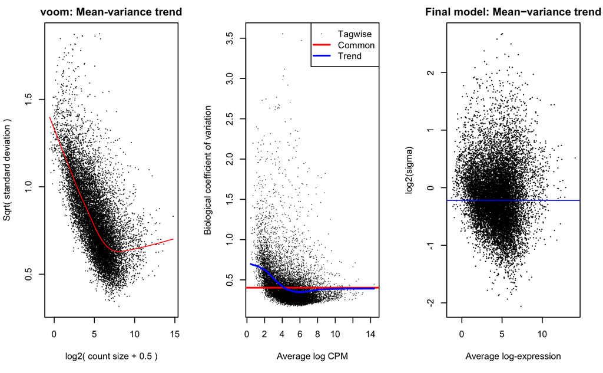

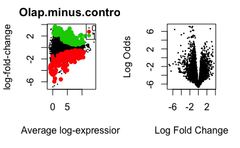

```r
#Perform DE
DE.data <- DE.run(rnaseq$mouse,d,2,cont.matrix = cont.matrix)
```

```r
#Top DE genes table
DE <- topTable.annotated.DE(DE.data$efit,p.val = 0.01,spec="mouse")
table(DE[,direction])
```

```
down.reg   up.reg
      55       15
```

```r
DE[direction=="up.reg",.(direction,ENSEMBL,SYMBOL,adj.P.Val,logFC)]
```

| direction | ENSEMBL | SYMBOL | adj.P.Val | logFC |
| --- | --- | --- | --- | --- |
| up.reg | ENSMUSG00000035042 | Ccl5 | 0.0008934619 | 2.8015335 |
| up.reg | ENSMUSG00000031779 | Ccl22 | 0.0019745493 | 3.1221961 |
| up.reg | ENSMUSG00000091649 | Phf11b | 0.0045527511 | 1.9725619 |
| up.reg | ENSMUSG00000002204 | Napsa | 0.0054078115 | 1.5572254 |
| up.reg | ENSMUSG00000032925 | Itgbl1 | 0.0057170383 | 1.6237653 |
| up.reg | ENSMUSG00000025498 | Irf7 | 0.0057170383 | 1.6553579 |
| up.reg | ENSMUSG00000029417 | Cxcl9 | 0.0075223191 | 3.2889773 |
| up.reg | ENSMUSG00000034652 | Cd300a | 0.0075223191 | 1.3261684 |
| up.reg | ENSMUSG00000022548 | Apod | 0.0075395518 | 1.9211912 |
| up.reg | ENSMUSG00000030148 | Clec4a2 | 0.0089122259 | 1.4577341 |

[output cut: 5 more lines]

```r
DE[direction=="down.reg",.(direction,ENSEMBL,SYMBOL,adj.P.Val,logFC)]
```

| direction | ENSEMBL | SYMBOL | adj.P.Val | logFC |
| --- | --- | --- | --- | --- |
| down.reg | ENSMUSG00000000317 | Bcl6b | 0.0008675096 | -2.1357345 |
| down.reg | ENSMUSG00000001435 | Col18a1 | 0.0008675096 | -1.3541576 |
| down.reg | ENSMUSG00000034684 | Sema3f | 0.0008675096 | -1.8445748 |
| down.reg | ENSMUSG00000033788 | Dysf | 0.0008675096 | -1.4818382 |
| down.reg | ENSMUSG00000020911 | Krt19 | 0.0008675096 | -5.5691514 |
| down.reg | ENSMUSG00000034205 | Loxl2 | 0.0009722168 | -1.3387675 |
| down.reg | ENSMUSG00000034205 | Gm21451 | 0.0009722168 | -1.3387675 |
| down.reg | ENSMUSG00000031502 | Col4a1 | 0.0009722168 | -1.1228147 |
| down.reg | ENSMUSG00000030123 | Plxnd1 | 0.0009722168 | -1.1759186 |
| down.reg | ENSMUSG00000020439 | Smtn | 0.0010143030 | -1.7855748 |

[output cut: 45 more lines]

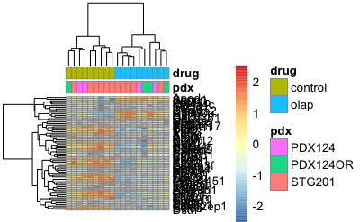

```r
#Pheatmap w/ batch correction
i <- match(DE$ENSEMBL,rownames(DE.data$v$E))
y <- removeBatchEffect(DE.data$v$E[i,],design = model.matrix(~drug), batch= pdx)
labels.col <- rep("",nrow(rnaseq$meta))
labels.row <- DE$SYMBOL
ann.col <- as.data.frame(rnaseq$meta[,.(pdx,drug)])
rownames(ann.col) <- rnaseq$meta[,Sample.name]
pheatmap(y,labels_col=labels.col,labels_row=labels.row,annotation_col = ann.col,scale="row")
```

```r
#GSEA - c6
gsea <- GSEA.run(DE.data$v,d,cont.matrix[,1],Mm.c6,0.01,spec="mouse")
gsea[Direction=="Up",.(rn,NGenes,Direction,FDR)]
```

| rn | NGenes | Direction | FDR |
| --- | --- | --- | --- |

```r
gsea[Direction=="Down",.(rn,NGenes,Direction,FDR)]
```

| rn | NGenes | Direction | FDR |
| --- | --- | --- | --- |

```r
#GSEA - c2
gsea <- GSEA.run(DE.data$v,d,cont.matrix[,1],Mm.c2,0.01,spec="mouse")
gsea[Direction=="Up",.(rn,NGenes,Direction,FDR)]
```

| rn | NGenes | Direction | FDR |
| --- | --- | --- | --- |
| MOSERLE_IFNA_RESPONSE | 58 | Up | 9.318362e-06 |
| BOWIE_RESPONSE_TO_EXTRACELLULAR_MATRIX | 39 | Up | 5.791684e-05 |
| BOWIE_RESPONSE_TO_TAMOXIFEN | 39 | Up | 5.791684e-05 |
| ZHANG_INTERFERON_RESPONSE | 40 | Up | 9.096436e-04 |
| LI_WILMS_TUMOR_ANAPLASTIC_DN | 15 | Up | 9.395749e-04 |
| FARMER_BREAST_CANCER_CLUSTER_1 | 49 | Up | 1.227338e-03 |
| REACTOME_INTERFERON_GAMMA_SIGNALING | 82 | Up | 1.472540e-03 |
| REACTOME_INTERFERON_ALPHA_BETA_SIGNALING | 75 | Up | 2.000168e-03 |
| KIM_LRRC3B_TARGETS | 65 | Up | 2.229192e-03 |
| BIOCARTA_CTLA4_PATHWAY | 24 | Up | 2.259798e-03 |

[output cut: 15 more lines]

```r
gsea[Direction=="Down",.(rn,NGenes,Direction,FDR)]
```

| rn | NGenes | Direction | FDR |
| --- | --- | --- | --- |
| ZHAN_MULTIPLE_MYELOMA_PR_UP | 39 | Down | 0.0002920183 |
| SCIAN_CELL_CYCLE_TARGETS_OF_TP53_AND_TP73_DN | 25 | Down | 0.0005487720 |
| MONTERO_THYROID_CANCER_POOR_SURVIVAL_UP | 14 | Down | 0.0006593915 |
| SEMENZA_HIF1_TARGETS | 47 | Down | 0.0007847798 |
| LY_AGING_MIDDLE_DN | 20 | Down | 0.0009367137 |
| WACKER_HYPOXIA_TARGETS_OF_VHL | 21 | Down | 0.0009367137 |
| KUMAMOTO_RESPONSE_TO_NUTLIN_3A_DN | 14 | Down | 0.0010278400 |
| CROONQUIST_NRAS_SIGNALING_DN | 84 | Down | 0.0011688310 |
| WHITFIELD_CELL_CYCLE_LITERATURE | 47 | Down | 0.0012273376 |
| BIOCARTA_GLYCOLYSIS_PATHWAY | 17 | Down | 0.0012273376 |

[output cut: 53 more lines]

```
Estimating GSVA scores for 4463 gene sets.
Computing observed enrichment scores
Estimating ECDFs in rnaseq data with Poisson kernels
Using parallel with 4 cores
```

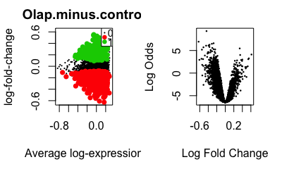

```r
# ssGSEA
ssGSEA.data <- ssGSEA.run(DE.data$v$E,Mm.c2,d,cont.matrix=cont.matrix,spec = "mouse")
```

```r
#Top DE gene.sets table
ssGSEA <- topTable.annotated.ssGSEA(ssGSEA.data$efit,p.val = 0.01)
ssGSEA[direction=="up.reg",.(direction,gene.set,adj.P.Val,logFC)]
```

| direction | gene.set | adj.P.Val | logFC |
| --- | --- | --- | --- |
| up.reg | SHANK_TAL1_TARGETS_DN | 0.000548824 | 0.3381971 |
| up.reg | ISHIKAWA_STING_SIGNALING | 0.001006071 | 0.6138633 |
| up.reg | APPEL_IMATINIB_RESPONSE | 0.001061000 | 0.3488370 |
| up.reg | BOWIE_RESPONSE_TO_TAMOXIFEN | 0.001532240 | 0.5524904 |
| up.reg | BOWIE_RESPONSE_TO_EXTRACELLULAR_MATRIX | 0.001548184 | 0.5395192 |
| up.reg | BOSCO_INTERFERON_INDUCED_ANTIVIRAL_MODULE | 0.001548184 | 0.3996425 |
| up.reg | KIM_LRRC3B_TARGETS | 0.001579331 | 0.3719187 |
| up.reg | MORI_LARGE_PRE_BII_LYMPHOCYTE_DN | 0.001598146 | 0.2763354 |
| up.reg | WAGNER_APO2_SENSITIVITY | 0.001654559 | 0.2249716 |
| up.reg | LI_WILMS_TUMOR_ANAPLASTIC_DN | 0.001663322 | 0.3932074 |

[output cut: 77 more lines]

```r
ssGSEA[direction=="down.reg",.(direction,gene.set,adj.P.Val,logFC)]
```

| direction | gene.set | adj.P.Val | logFC |
| --- | --- | --- | --- |
| down.reg | XU_HGF_SIGNALING_NOT_VIA_AKT1_6HR | 0.0001072744 | -0.4411547 |
| down.reg | ZHOU_CELL_CYCLE_GENES_IN_IR_RESPONSE_2HR | 0.0004336214 | -0.6264552 |
| down.reg | BERENJENO_TRANSFORMED_BY_RHOA_FOREVER_DN | 0.0004336214 | -0.2746738 |
| down.reg | KEGG_BLADDER_CANCER | 0.0004336214 | -0.3152178 |
| down.reg | LOPEZ_MESOTHELIOMA_SURVIVAL_OVERALL_DN | 0.0004336214 | -0.3703062 |
| down.reg | RANKIN_ANGIOGENIC_TARGETS_OF_VHL_HIF2A_DN | 0.0004336214 | -0.3925540 |
| down.reg | PODAR_RESPONSE_TO_ADAPHOSTIN_DN | 0.0004336214 | -0.3865726 |
| down.reg | SU_PLACENTA | 0.0004336214 | -0.4504014 |
| down.reg | YAO_TEMPORAL_RESPONSE_TO_PROGESTERONE_CLUSTER_4 | 0.0005054260 | -0.3723273 |
| down.reg | PHONG_TNF_TARGETS_DN | 0.0005054260 | -0.5128577 |

[output cut: 488 more lines]

[figure not shown]

```r
#Pheatmap w/ batch correction
i <- match(ssGSEA$gene.set,rownames(ssGSEA.data$w))
y <- removeBatchEffect(ssGSEA.data$w[i,],design = model.matrix(~drug), batch=pdx)
labels.col <- rep("",nrow(rnaseq$meta))
labels.row <- ssGSEA$gene.set
ann.col <- as.data.frame(rnaseq$meta[,.(pdx,drug)])
rownames(ann.col) <- rnaseq$meta[,Sample.name]
pheatmap(y,labels_col=labels.col,labels_row=labels.row,annotation_col = ann.col,scale="row")
```

The DE ran smooth with a reasonably good common dispersion value (<0.5). This leads to a number of genes being identified as DE when accounting for tissue differences. Notably, and as seen in the human reads, there appears an up.regulation of immmuno pathways associated with the presence of the drug as noted via chemokines. Opposing this seems to be a down regulation in core cell pathways, namely glycolysis, mitosis, etc, alongside the presences of hypoxia. In addition, the ssGSEA reports far too many pathways as DE, which may be due to the low amount of reads associated with the mouse stroma. As such, we should discard this analysis.

As an aside, let us check the coefficients associated with the different PDX models.

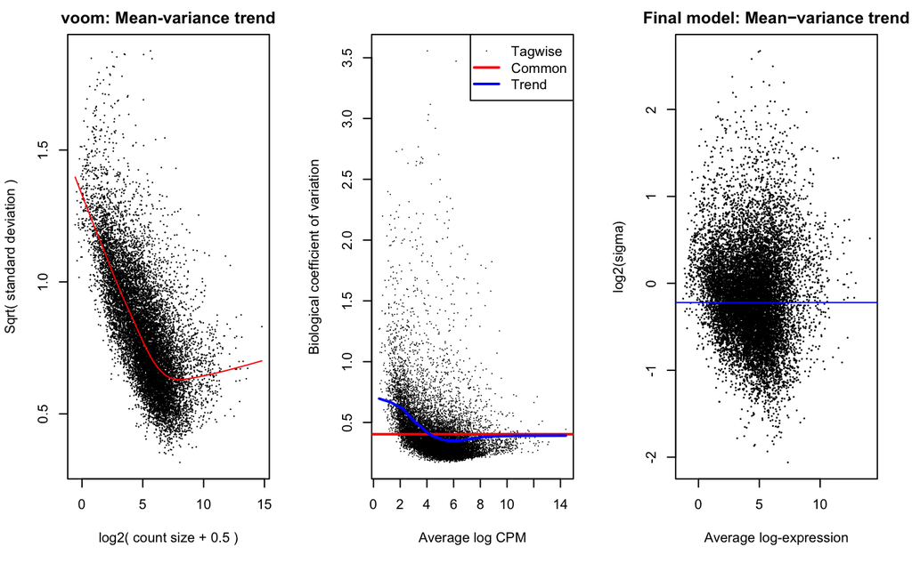

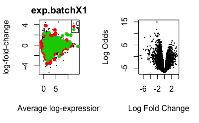

```r
drug <- make.names(rnaseq$meta$drug)
pdx <- make.names(rnaseq$meta$pdx)
exp.batch <- make.names(rnaseq$meta$exp.batch)
d <- model.matrix(~ drug + pdx + exp.batch)
d <- d[,colnames(d) != "exp.batchX2"]
#Perform DE
DE.data <- DE.run(rnaseq$mouse,d,2,coefs = 2:5)
```

```r
#Top DE genes table
DE <- decideTest.annotated.DE(DE.data$efit,p.val = 0.01,spec="mouse")
summary(apply(DE[,2:5],2,factor))
```

```
 drugolap  pdxPDX124OR pdxSTG201 exp.batchX1
 -1: 448   0:3993      -1:2019   0:3992
 0 :3323               0 : 544   1:   1
 1 : 222               1 :1430
```

There is a very large difference between STG201 and PDX124(OR), and little difference between PDX124 and PDX124OR. This is suprising somewhat considering that this is analysis on the mouse stroma.

## Model: ~ drug:pdx

As with human, though of less importance, one issue with the abova analysis is that it contains the model that has innate resistance, which could react in a different manner than the other PDX models. Let us look at the tissue types individually to see if this is true.

```r
drug <- make.names(rnaseq$meta$drug)
pdx <- make.names(rnaseq$meta$pdx)
exp.batch <- make.names(rnaseq$meta$exp.batch)
d <- model.matrix(~ 0 + drug:pdx + exp.batch:pdx)
d <- d[,colSums(d)!=0]
d <- d[,colnames(d) != "pdxSTG201:exp.batchX2"]
cont.matrix <- matrix(c(c(-1,1,0,0,0,0,0),
            c(0,0,-1,1,0,0,0),
            c(0,0,0,0,-1,1,0)),
            dim(d)[2], 3)
colnames(cont.matrix) <- paste(sort(unique(pdx)),"Olap.minus.control",sep=":")
rownames(cont.matrix) <- colnames(d)
cont.matrix
```

```
                        PDX124:Olap.minus.control PDX124OR:Olap.minus.control STG201:Olap.minus.control
drugcontrol:pdxPDX124                          -1                           0                         0
drugolap:pdxPDX124                              1                           0                         0
drugcontrol:pdxPDX124OR                         0                          -1                         0
drugolap:pdxPDX124OR                            0                           1                         0
drugcontrol:pdxSTG201                           0                           0                        -1
drugolap:pdxSTG201                              0                           0                         1
pdxSTG201:exp.batchX1                           0                           0                         0
```

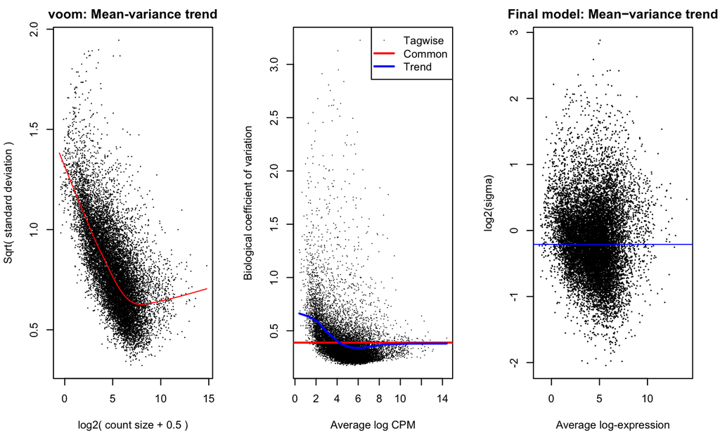

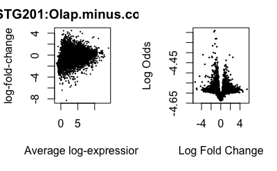

```r
DE.data <- DE.run(rnaseq$mouse,d,2,cont.matrix = cont.matrix)
```

```r
#Table of DE genes
DE <- decideTest.annotated.DE(DE.data$efit,p.val = 0.01,spec = "mouse")
DE
```

| ENSEMBL | PDX124:Olap.minus.control | PDX124OR:Olap.minus.control | STG201:Olap.minus.control | ENTREZID | SYMBOL | GENENAME |
| --- | --- | --- | --- | --- | --- | --- |
| ENSMUSG00000025902 | 0 | 0 | -1 | 20671 | Sox17 | SRY (sex determining region Y)-box 17 |
| ENSMUSG00000026121 | 0 | 0 | -1 | 20353 | Sema4c | sema domain, immunoglobulin domain (Ig), transmembrane domain (TM) and short cytoplasmic domain, (semaphorin) 4C |
| ENSMUSG00000018417 | 0 | 0 | -1 | 17912 | Myo1b | myosin IB |
| ENSMUSG00000026104 | 0 | 0 | 1 | 20846 | Stat1 | signal transducer and activator of transcription 1 |
| ENSMUSG00000042807 | 0 | 0 | -1 | 329152 | Hecw2 | HECT, C2 and WW domain containing E3 ubiquitin protein ligase 2 |
| ENSMUSG00000026039 | 0 | 0 | -1 | 68549 | Sgol2a | shugoshin-like 2a (S. pombe) |
| ENSMUSG00000026014 | 0 | 0 | -1 | 77300 | Raph1 | Ras association (RalGDS/AF-6) and pleckstrin homology domains 1 |
| ENSMUSG00000025969 | 0 | 0 | -1 | 18187 | Nrp2 | neuropilin 2 |
| ENSMUSG00000070871 | 0 | 0 | -1 | 227210 | Ccnyl1 | cyclin Y-like 1 |
| ENSMUSG00000026170 | 0 | 0 | 1 | 104086 | Cyp27a1 | cytochrome P450, family 27, subfamily a, polypeptide 1 |

[output cut: 827 more lines]

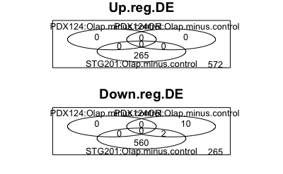

```r
#VennDiagrms of DE genes
vennDiagram.paired(DE[,2:4])
```

# OR reduced.

## Model: ~ 0 + drug + pdx

```r
rnaseq.noOR <- subset.PDX(rnaseq,rnaseq$meta[,pdx!="PDX124OR"]
           )
drug <- make.names(rnaseq.noOR$meta$drug)
pdx <- make.names(rnaseq.noOR$meta$pdx)
exp.batch <- make.names(rnaseq.noOR$meta$exp.batch)
d <- model.matrix(~ 0 + drug + pdx + exp.batch)
d <- d[,colnames(d) != "exp.batchX2"]
cont.matrix <- matrix(c(-1,1,rep(0,dim(d)[2]-2)), dim(d)[2], 1)
colnames(cont.matrix) <- c("Olap.minus.control")
rownames(cont.matrix) <- colnames(d)
cont.matrix
```

```
            Olap.minus.control
drugcontrol                 -1
drugolap                     1
pdxSTG201                    0
exp.batchX1                  0
```

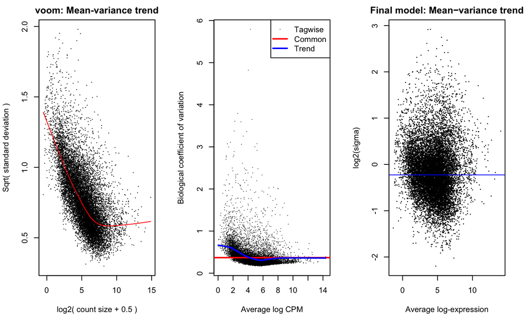

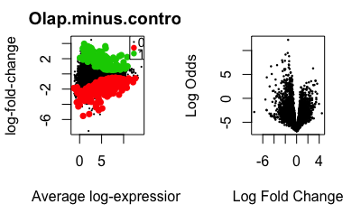

```r
#Perform DE
DE.data <- DE.run(rnaseq.noOR$mouse,d,2,cont.matrix = cont.matrix)
```

```r
#Top DE genes table
DE <- topTable.annotated.DE(DE.data$efit,p.val = 0.01,spec = "mouse")
table(DE[,direction])
```

```
down.reg   up.reg
     145       35
```

```r
DE[direction=="up.reg",.(direction,ENSEMBL,SYMBOL,adj.P.Val,logFC,GENENAME)]
```

| direction | ENSEMBL | SYMBOL | adj.P.Val | logFC | GENENAME |
| --- | --- | --- | --- | --- | --- |
| up.reg | ENSMUSG00000035042 | Ccl5 | 0.0005828523 | 2.9225134 | chemokine (C-C motif) ligand 5 |
| up.reg | ENSMUSG00000045826 | Ptprcap | 0.0018843164 | 3.3416040 | protein tyrosine phosphatase, receptor type, C polypeptide-associated protein |
| up.reg | ENSMUSG00000023078 | Cxcl13 | 0.0028763780 | 3.3597783 | chemokine (C-X-C motif) ligand 13 |
| up.reg | ENSMUSG00000079298 | Klrb1b | 0.0025889238 | 2.5720237 | killer cell lectin-like receptor subfamily B member 1B |
| up.reg | ENSMUSG00000091649 | Phf11b | 0.0034318690 | 2.1691131 | PHD finger protein 11B |
| up.reg | ENSMUSG00000032925 | Itgbl1 | 0.0034826376 | 1.7321398 | integrin, beta-like 1 |
| up.reg | ENSMUSG00000029417 | Cxcl9 | 0.0038335409 | 3.6438549 | chemokine (C-X-C motif) ligand 9 |
| up.reg | ENSMUSG00000031779 | Ccl22 | 0.0028763780 | 3.1551316 | chemokine (C-C motif) ligand 22 |
| up.reg | ENSMUSG00000024675 | Ms4a4c | 0.0041336501 | 2.9726849 | membrane-spanning 4-domains, subfamily A, member 4C |
| up.reg | ENSMUSG00000046031 | Fam26f | 0.0038616857 | 2.9774296 | family with sequence similarity 26, member F |

[output cut: 25 more lines]

```r
DE[direction=="down.reg",.(direction,ENSEMBL,SYMBOL,adj.P.Val,logFC,GENENAME)]
```

| direction | ENSEMBL | SYMBOL | adj.P.Val | logFC | GENENAME |
| --- | --- | --- | --- | --- | --- |
| down.reg | ENSMUSG00000001435 | Col18a1 | 1.851899e-05 | -1.5065238 | collagen, type XVIII, alpha 1 |
| down.reg | ENSMUSG00000034205 | Loxl2 | 1.494205e-04 | -1.5807453 | lysyl oxidase-like 2 |
| down.reg | ENSMUSG00000034205 | Gm21451 | 1.494205e-04 | -1.5807453 | predicted gene, 21451 |
| down.reg | ENSMUSG00000020439 | Smtn | 1.494205e-04 | -1.9635821 | smoothelin |
| down.reg | ENSMUSG00000031502 | Col4a1 | 1.692709e-04 | -1.3370948 | collagen, type IV, alpha 1 |
| down.reg | ENSMUSG00000068735 | Trp53i11 | 2.550019e-04 | -2.5687261 | transformation related protein 53 inducible protein 11 |
| down.reg | ENSMUSG00000034684 | Sema3f | 2.550019e-04 | -2.0697192 | sema domain, immunoglobulin domain (Ig), short basic domain, secreted, (semaphorin) 3F |
| down.reg | ENSMUSG00000029581 | Fscn1 | 2.550019e-04 | -1.3276970 | fascin actin-bundling protein 1 |
| down.reg | ENSMUSG00000015468 | Notch4 | 2.550019e-04 | -2.4840569 | notch 4 |
| down.reg | ENSMUSG00000026421 | Csrp1 | 3.925461e-04 | -1.3900428 | cysteine and glycine-rich protein 1 |

[output cut: 135 more lines]

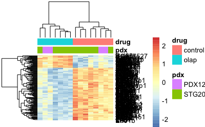

```r
#Pheatmap w/ batch correction
i <- match(DE$ENSEMBL,rownames(DE.data$v$E))
y <- removeBatchEffect(DE.data$v$E[i,],design = model.matrix(~drug), batch= pdx)
labels.col <- rep("",nrow(rnaseq.noOR$meta))
labels.row <- DE$SYMBOL
ann.col <- as.data.frame(rnaseq.noOR$meta[,.(pdx,drug)])
rownames(ann.col) <- rnaseq.noOR$meta[,Sample.name]
pheatmap(y,labels_col=labels.col,labels_row=labels.row,annotation_col = ann.col,scale="row")
```

```r
#GSEA - c6
gsea <- GSEA.run(DE.data$v,d,cont.matrix[,1],Mm.c6,0.05,spec = "mouse")
gsea[Direction=="Up",.(rn,NGenes,Direction,FDR)]
```

| rn | NGenes | Direction | FDR |
| --- | --- | --- | --- |

```r
gsea[Direction=="Down",.(rn,NGenes,Direction,FDR)]
```

| rn | NGenes | Direction | FDR |
| --- | --- | --- | --- |

```r
#GSEA - c2
gsea <- GSEA.run(DE.data$v,d,cont.matrix[,1],Mm.c2,0.05,spec = "mouse")
gsea[Direction=="Up",.(rn,NGenes,Direction,FDR)]
```

| rn | NGenes | Direction | FDR |
| --- | --- | --- | --- |
| MOSERLE_IFNA_RESPONSE | 58 | Up | 9.176113e-05 |
| BOWIE_RESPONSE_TO_EXTRACELLULAR_MATRIX | 39 | Up | 1.523999e-04 |
| BOWIE_RESPONSE_TO_TAMOXIFEN | 39 | Up | 1.523999e-04 |
| ZHANG_INTERFERON_RESPONSE | 40 | Up | 1.171624e-03 |
| REACTOME_INTERFERON_GAMMA_SIGNALING | 83 | Up | 2.539961e-03 |
| REACTOME_INTERFERON_ALPHA_BETA_SIGNALING | 75 | Up | 2.648237e-03 |
| LI_WILMS_TUMOR_ANAPLASTIC_DN | 15 | Up | 2.648237e-03 |
| KIM_LRRC3B_TARGETS | 65 | Up | 2.891769e-03 |
| GRANDVAUX_IFN_RESPONSE_NOT_VIA_IRF3 | 22 | Up | 3.029181e-03 |
| ISHIKAWA_STING_SIGNALING | 7 | Up | 3.033325e-03 |

[output cut: 25 more lines]

```r
gsea[Direction=="Down",.(rn,NGenes,Direction,FDR)]
```

| rn | NGenes | Direction | FDR |
| --- | --- | --- | --- |
| ZHAN_MULTIPLE_MYELOMA_PR_UP | 41 | Down | 9.176113e-05 |
| MONTERO_THYROID_CANCER_POOR_SURVIVAL_UP | 14 | Down | 9.929525e-05 |
| SCIAN_CELL_CYCLE_TARGETS_OF_TP53_AND_TP73_DN | 24 | Down | 1.523999e-04 |
| LY_AGING_MIDDLE_DN | 20 | Down | 1.535035e-04 |
| FARDIN_HYPOXIA_9 | 8 | Down | 1.535035e-04 |
| WACKER_HYPOXIA_TARGETS_OF_VHL | 21 | Down | 2.304346e-04 |
| CROONQUIST_NRAS_SIGNALING_DN | 82 | Down | 2.833375e-04 |
| KANG_DOXORUBICIN_RESISTANCE_UP | 59 | Down | 2.833375e-04 |
| GREENBAUM_E2A_TARGETS_UP | 38 | Down | 2.833375e-04 |
| KUMAMOTO_RESPONSE_TO_NUTLIN_3A_DN | 13 | Down | 2.833375e-04 |

[output cut: 255 more lines]

So even though we have removed data, we are returned far more DE genes than before. This would indicate that we are correct in our hypothesis to remove the OR model for this analysis to be correct as even the mouse reacts differently to treatment when the tumour is resistant.

Lastly, though we lack samples, we can attempt to model with interaction terms, incase the PDX models react in different ways. I suspect that this analysis is dominated by changes in STG201 due to the unbalanced data set.

## Model: ~ 0 + drug * pdx

```r
rnaseq.noOR <- subset.PDX(rnaseq,rnaseq$meta[,pdx!="PDX124OR"]
           )
drug <- make.names(rnaseq.noOR$meta$drug)
pdx <- make.names(rnaseq.noOR$meta$pdx)
exp.batch <- make.names(rnaseq.noOR$meta$exp.batch)
d <- model.matrix(~ 0 + drug * pdx + exp.batch)
d <- d[,colnames(d) != "exp.batchX2"]
cont.matrix <- matrix(c(-1,1,rep(0,dim(d)[2]-2)), dim(d)[2], 1)
colnames(cont.matrix) <- c("Olap.minus.control")
rownames(cont.matrix) <- colnames(d)
cont.matrix
```

```
                   Olap.minus.control
drugcontrol                        -1
drugolap                            1
pdxSTG201                           0
exp.batchX1                         0
drugolap:pdxSTG201                  0
```

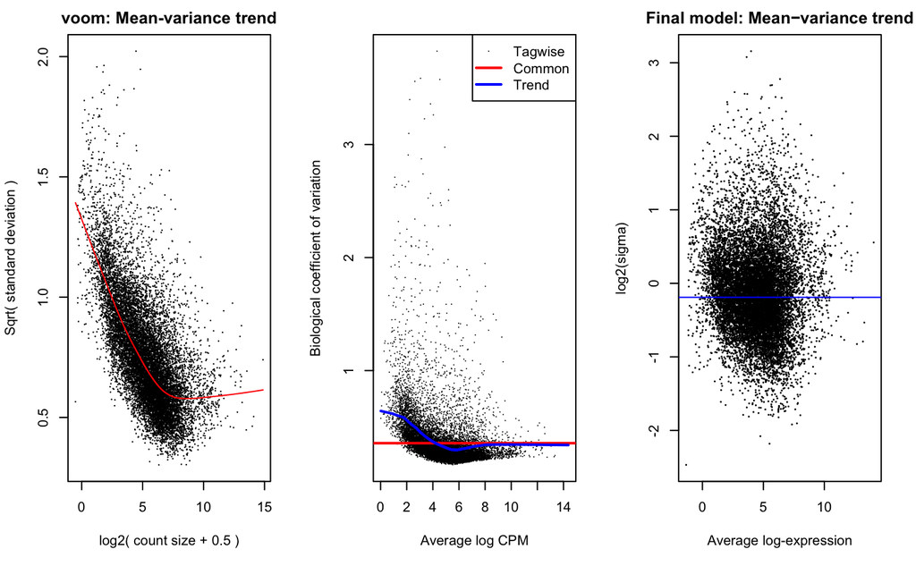

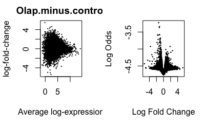

```r
#Perform DE
DE.data <- DE.run(rnaseq.noOR$mouse,d,2,cont.matrix = cont.matrix)
```

```r
#Top DE genes table
DE <- topTable.annotated.DE(DE.data$efit,p.val = 0.05,spec = "mouse")
```

```
Error in topTable.annotated(efit, lfc, p.val) : No DE genes
```

As we predicted, we remove all genes notes as DE. This could be due to the unbalanced dataset, as mentioned above, or the introduction of new coefficents which reduces the overall statisical power.

Let us check the interaction coefficient (and others).

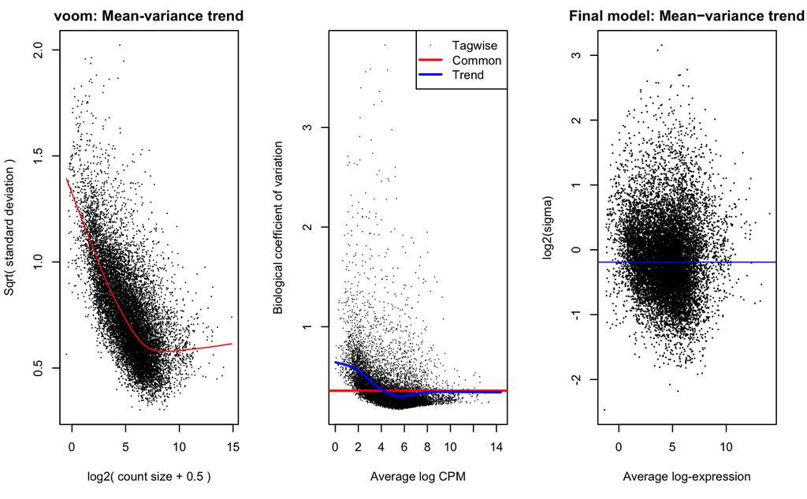

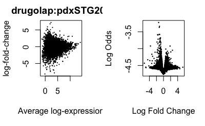

```r
drug <- make.names(rnaseq.noOR$meta$drug)
pdx <- make.names(rnaseq.noOR$meta$pdx)
exp.batch <- make.names(rnaseq.noOR$meta$exp.batch)
d <- model.matrix(~ drug * pdx + exp.batch)
d <- d[,colnames(d) != "exp.batchX2"]
#Perform DE
DE.data <- DE.run(rnaseq.noOR$mouse,d,2,coefs = 2:5)
```

```r
#Top DE genes table
DE <- decideTest.annotated.DE(DE.data$efit,p.val = 0.01,spec="mouse")
summary(apply(DE[,2:5],2,factor))
```

```
 drugolap pdxSTG201 exp.batchX1 drugolap:pdxSTG201
 0:1754   -1:1386   0:1753      0:1754
          1 : 368   1:   1
```

Interestingly the interaction term reports zero genes as DE. This is a reflection of the unbalanced data set. We also note that STG201 is very different to PDX124.